# Projeto - NLP

Ricardo B Garcia rbgarcia@gmail.com

Projeto didático do Módulo de Machine Learning com o objetivo de explorar diversos recursos de Processamento de Linguagem Natural, como tipos de representações (bag of words, TF-IDF e word2vec) e o desempenho de diferentes tipos de modelo (random forest, lightGBM e Naïve Bayes).  
Data: 01/2022  
Professor: Helder Vieira (Data Scientist - Itaú)

## Proposta

Os segundo projeto do módulo de Machine Learning será focado no processamento de linguagem natural! Usaremos os algoritmos aprendidos e as técnicas vistas na segunda parte do curso para extrairmos informações relevantes de texto. Mais precisamente, de publicações no Twitter.

## Os Dados

Utilizaremos um Dataset obtido do Twitter com 100K postagens entre os dias 01/08/2018 e 20/10/2018. Cada postagem é classificada como **positiva**, **negativa** ou **neutra**.

Dois arquivos serão disponilizados para o desenvolvimento dos modelos, um para treino/validação e outro para submissão. Os arquivos se encontram na pasta */Dados/train* e */Dados/subm*, respectivamente.

Descrição das colunas:

- **id**: ID único para o tweet
- **tweet_text**: Texto da publicação no Twitter
- **tweet_date**: Data da publicação no Twitter
- **sentiment**: 0, se negativo; 1, se positivo; 2, se neutro
- **query_used**: Filtro utilizado para buscar a publicação

## O Problema

Você deverá desenvolver um modelo para detectar o sentimento de uma publicação do Twitter a classificando em uma das três categorias: **positiva**, **negativa** ou **neutra**. O texto da publicação está disponível na coluna "tweet_text". Teste pelo menos 3 técnicas de NLP diferentes e escolha a métrica de avaliação que julgar mais pertinente.

Escolha o melhor modelo e gere uma base a partir dos dados de submissão, que estão no caminho `Dados/subm/Subm3Classes.csv`, com o seguinte formato:

| id | sentiment_predict |
| --- | --- |
| 12123232 | 0 |
| 323212 | 1 |
| 342235 | 2 |

Salve essa tabela como um arquivo csv com o nome `<nome>_<sobrenome>_nlp_degree.csv` e submeta-o como parte da entrega final do projeto.

# Desenvolvimento do projeto

# 1. Divisão da base de teste

```python
# Importação de bibliotecas
import pandas as pd
import numpy as np
import matplotlib.pyplot as plt
import seaborn as sns
```

```python
# Carregando os dados
df_train = pd.read_csv('Dados/train/Train3classes.csv')
df_train.head()
```

|  | id | tweet_text | tweet_date | sentiment | query_used |
| --- | --- | --- | --- | --- | --- |
| 0 | 1049721159292346368 | Rio elege maior bancada policial de sua histór... | Tue Oct 09 18:00:01 +0000 2018 | 2 | folha |
| 1 | 1046251157025423360 | fiquei tão triste quando eu vi o preço da câme... | Sun Sep 30 04:11:28 +0000 2018 | 0 | :( |
| 2 | 1041744620206653440 | Para Theresa May, seu plano para o Brexit é a ... | Mon Sep 17 17:44:06 +0000 2018 | 2 | exame |
| 3 | 1046937084727107589 | caralho eu quero proteger a danielly em um pot... | Tue Oct 02 01:37:06 +0000 2018 | 0 | :( |
| 4 | 1047326854229778432 | @SiCaetano_ viva o caos :) | Wed Oct 03 03:25:55 +0000 2018 | 1 | :) |

```python
# Resumo do DF
df_train.info()
```

```
<class 'pandas.core.frame.DataFrame'>
RangeIndex: 95000 entries, 0 to 94999
Data columns (total 5 columns):
 #   Column      Non-Null Count  Dtype
---  ------      --------------  -----
 0   id          95000 non-null  int64
 1   tweet_text  95000 non-null  object
 2   tweet_date  95000 non-null  object
 3   sentiment   95000 non-null  int64
 4   query_used  95000 non-null  object
dtypes: int64(2), object(3)
memory usage: 3.6+ MB
```

#### Separação de uma base de treino (df_exp) e outra de teste (df_test)

```python
# Separação da base: experiment e test (aprox. 90% e 10%)
df_exp = df_train.sample(85000,random_state=5)
df_test = df_train.drop(df_exp.index)
print(df_train.shape, df_exp.shape, df_test.shape)
```

```
(95000, 5) (85000, 5) (10000, 5)
```

# 2. Análise da consistência dos dados

A partir daqui somente trabalhamos com a base df_exp

## 2.1 Dados faltantes

```python
df_exp.isna().sum()
```

```
id            0
tweet_text    0
tweet_date    0
sentiment     0
query_used    0
dtype: int64
```

## 2.2 Dados duplicados

- Considero as colunas 'id','tweet_text','tweet_date' para detectar casos duplicados, pois pode ser que um mesmo tweet tenha sido selecionado por mais de uma query.

```python
# Comparando o shape do df antes e após drop de duplicados
n_duplicados = df_exp.duplicated(subset=['id','tweet_text','tweet_date']).sum()

print(f'{n_duplicados} casos duplicados em {len(df_exp)} registros')
```

```
12 casos duplicados em 85000 registros
```

```python
# Exclusão dos casos duplicados
df_exp.drop_duplicates(subset=['id','tweet_text','tweet_date'],inplace=True)
df_exp.shape
```

```
(84988, 5)
```

# 3. Análise exploratória

## 3.1 Queries usadas na seleção dos tweets

```python
print('\033[1m'+'Número de queries:'+'\033[0m',df_exp['query_used'].nunique())
print('\033[1m'+'Queries usadas:'+'\033[m',df_exp['query_used'].unique())
```

```
Número de queries: 14
Queries usadas: [':)' ':(' 'estadao' 'g1' '#noticia' 'folha' 'veja' 'jornaloglobo' '#fato'
 'exame' '#oportunidade' '#trabalho' '#curiosidade' '#novidade']
```

## 3.2 Distribuição do sentimento

```python
df_sentimentos = pd.DataFrame()
df_sentimentos['Sentimento'] = ['Negativo','Positivo','Neutro']
df_sentimentos['Contagem'] = df_exp['sentiment'].value_counts(sort=False)
df_sentimentos['Percentual'] = round(df_exp['sentiment'].value_counts(normalize=True, sort=False)*100,1)
df_sentimentos.index.rename('Código', inplace=True)
display(df_sentimentos)
```

| Código | Sentimento | Contagem | Percentual |
| --- | --- | --- | --- |
| 0 | Negativo | 28320 | 33.3 |
| 1 | Positivo | 28384 | 33.4 |
| 2 | Neutro | 28284 | 33.3 |

## 3.3 Relação entre sentimento e query

```python
print('\033[1m'+'Distribuição de sentimento de acordo com as queries'+'\033[0m')
print('Legenda: 0-negativo, 1-positivo, 2-neutro\n')
for item in df_exp['query_used'].unique():
    print('\033[1m'+'Query:'+'\033[0m',item)
    print('Contagem de sentimento:')
    display(df_exp[df_exp['query_used']==item]['sentiment'].value_counts())
    print('******************************')
```

```
Distribuição de sentimento de acordo com as queries
Legenda: 0-negativo, 1-positivo, 2-neutro

Query: :)
Contagem de sentimento:
```

```
1    28384
Name: sentiment, dtype: int64
```

```
Query: :(
Contagem de sentimento:
```

```
0    28320
Name: sentiment, dtype: int64
```

```
Query: estadao
Contagem de sentimento:
```

```
2    3468
Name: sentiment, dtype: int64
```

```
Query: g1
Contagem de sentimento:
```

```
2    3083
Name: sentiment, dtype: int64
```

```
Query: #noticia
Contagem de sentimento:
```

```
2    1012
Name: sentiment, dtype: int64
```

```
Query: folha
Contagem de sentimento:
```

```
2    4436
Name: sentiment, dtype: int64
```

```
Query: veja
Contagem de sentimento:
```

```
2    1919
Name: sentiment, dtype: int64
```

```
Query: jornaloglobo
Contagem de sentimento:
```

```
2    2114
Name: sentiment, dtype: int64
```

```
Query: #fato
Contagem de sentimento:
```

```
2    3095
Name: sentiment, dtype: int64
```

```
Query: exame
Contagem de sentimento:
```

```
2    3090
Name: sentiment, dtype: int64
```

```
Query: #oportunidade
Contagem de sentimento:
```

```
2    2171
Name: sentiment, dtype: int64
```

```
Query: #trabalho
Contagem de sentimento:
```

```
2    2726
Name: sentiment, dtype: int64
```

```
Query: #curiosidade
Contagem de sentimento:
```

```
2    343
Name: sentiment, dtype: int64
```

```
Query: #novidade
Contagem de sentimento:
```

```
2    827
Name: sentiment, dtype: int64
```

**Observações:**

- As queries " :) " e " :( " foram utilizadas para selecionar tweets classificados como positivos e negativos, respectivamente. As demais queries resultaram em tweets com classificação neutra.
- As correspondências entre queries e sentimentos precisam ser consideradas na elaboração do modelo, pois constituem regularidades facilmente captadas por algoritmos de Machine Learning. Dessa maneira, um modelo poderia ficar bem ajustado aos dados selecionados por essas queries, mas perderia o desempenho para tweets selecionados com outras queries.
- Em vista disso, pensando na maior generalização de um modelo para avaliação de tweets, é preciso que este capte outras informações a respeito do sentimento trazido por um tweet. Por isso, meu entendimento é que as queries devem ser excluídas do texto dos tweets, o que é possível fazer considerando elas como "stop words" durante o processo de tokenização. Essa decisão tem aspectos positivos e negativos: por um lado, permite retirar um importante viés do processo de modelagem, por outro, são informações perdidas pelo modelo.

## 3.4 Distribuição temporal dos dados

```python
# Conversão da coluna 'tweet_date' de 'object' para 'datetime'
df_exp['tweet_date'] = pd.to_datetime(df_exp['tweet_date'])

# Criação de coluna para armazenar somente a data (ano, mês, dia)
df_exp['Data'] = df_exp['tweet_date'].dt.strftime('%Y%m%d')

display(df_exp.info())
display(df_exp.head(3))
```

```
<class 'pandas.core.frame.DataFrame'>
Int64Index: 84988 entries, 80275 to 9639
Data columns (total 6 columns):
 #   Column      Non-Null Count  Dtype
---  ------      --------------  -----
 0   id          84988 non-null  int64
 1   tweet_text  84988 non-null  object
 2   tweet_date  84988 non-null  datetime64[ns, UTC]
 3   sentiment   84988 non-null  int64
 4   query_used  84988 non-null  object
 5   Data        84988 non-null  object
dtypes: datetime64[ns, UTC](1), int64(2), object(3)
memory usage: 4.5+ MB
```

```
None
```

|  | id | tweet_text | tweet_date | sentiment | query_used | Data |
| --- | --- | --- | --- | --- | --- | --- |
| 80275 | 1049107508105814016 | @softkirari Mas tenho alguns desse :) https://... | 2018-10-08 01:21:36+00:00 | 1 | :) | 20181008 |
| 64878 | 1046972849427230721 | tem snap miguelito? — não, desculpa :( https:/... | 2018-10-02 03:59:13+00:00 | 0 | :( | 20181002 |
| 27184 | 1046925068385890304 | @karinalouz Que pesado :( | 2018-10-02 00:49:21+00:00 | 0 | :( | 20181002 |

```python
# Contagem de tweets por dia
print('\033[1m'+'Contagem de tweets nos 5 primeiros e últimos dias'+'\033[0m')
display(df_exp.groupby(by=['Data'])['id'].count().head())
display(df_exp.groupby(by=['Data'])['id'].count().tail())
```

```
Contagem de tweets nos 5 primeiros e últimos dias
```

```
Data
20180809      1
20180817    202
20180818    191
20180819    145
20180820    297
Name: id, dtype: int64
```

```
Data
20181015    138
20181016    193
20181017    219
20181018    252
20181019    184
Name: id, dtype: int64
```

```python
# Deletando dia com único tweet
df_exp.drop(df_exp[df_exp['Data']=='20180809'].index,inplace=True)
```

```python
# Resumo das informações temporais
print('\033[1m'+'Data inicial:'+'\033[0m', df_exp['Data'].min())
print('\033[1m'+'Data final:'+'\033[0m', df_exp['Data'].max())
print('\033[1m'+'Dias:'+'\033[0m',(df_exp['tweet_date'].max()-df_exp['tweet_date'].min()).days)
```

```
Data inicial: 20180817
Data final: 20181019
Dias: 63
```

```python
# Contagem de tweets por dia
print('\033[1m'+'Número mínimo e máximo de tweets em um único dia'+'\033[0m')
print('\033[1m'+'Mínimo:'+'\033[0m',df_exp.groupby(by=['Data'])['id'].count().min())
print('\033[1m'+'Máximo:'+'\033[0m',df_exp.groupby(by=['Data'])['id'].count().max())
```

```
Número mínimo e máximo de tweets em um único dia
Mínimo: 51
Máximo: 16001
```

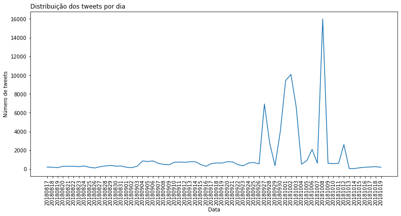

```python
df_tweets_dia = df_exp.groupby(by=['Data'])[['id']].count().reset_index()

plt.figure(figsize=(13,6))
plt.xticks(rotation=90)
plt.title('Distribuição dos tweets por dia', loc='left')
plt.ylabel('Número de tweets')
sns.lineplot(data=df_tweets_dia, y='id', x='Data');
```

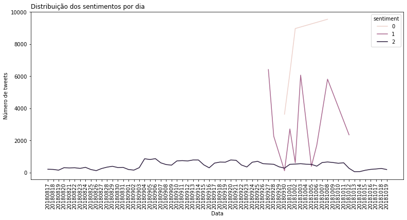

```python
df_sentimento_dia = df_exp.groupby(by=['Data','sentiment'])[['id']].count().reset_index()

plt.figure(figsize=(13,6))
plt.xticks(rotation=90)
plt.title('Distribuição dos sentimentos por dia',loc='left')
plt.ylabel('Número de tweets')
sns.lineplot(data=df_sentimento_dia,y='id',x='Data',hue='sentiment');
```

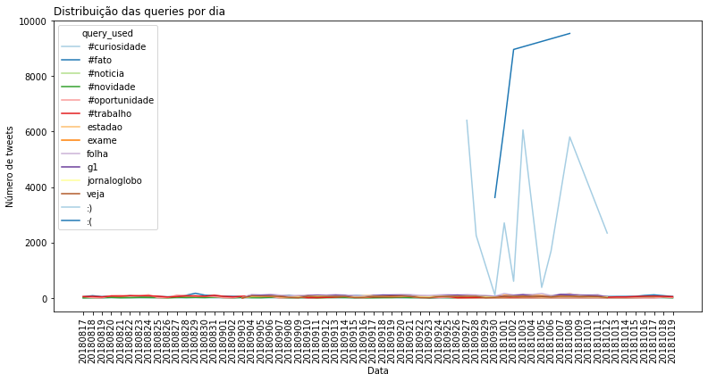

```python
df_query_dia = df_exp.groupby(by=['Data','query_used'])[['id']].count().reset_index()
qualitative_colors = sns.color_palette("Paired", 14)
plt.figure(figsize=(13,6))
plt.xticks(rotation=90)
plt.title('Distribuição das queries por dia',loc='left')
plt.ylabel('Número de tweets')
sns.lineplot(data=df_query_dia,y='id',x='Data',hue='query_used',palette=qualitative_colors);
```

**Observação:**

- Os tweeets com sentimentos positivos e negativos se concentram em poucos dias e durante o período eleitoral de 2018.

## 3.5 Texto dos tweets

```python
# importação de bibliotecas úteis
import re # Para trabalhar com expressões regulares
from wordcloud import WordCloud # Para fazer wordclouds

# Criando a função para criar wordclouds
def plot_wordcloud(texts):
    plt.figure(figsize=(10, 10))
    text = ' '.join(texts.tolist())
    WC = WordCloud(width=1000, height=500, max_words=500, min_font_size=5)
    words = WC.generate(text)
    plt.imshow(words, interpolation='bilinear')
    plt.show()
```

### 3.5.1 Texto antes do tratamento

- Sabemos que o tipo de escrita no Twitter tem uma série de particularidades, tais como: uso de hashtags #, uso de emoticons (:D, :), :(, :(( ) e emojis 🚀, marcação de usuários @usuário, links tipo "https://", números, entre outros. Vejamos um sample de tweets:

```python
print(df_exp[['tweet_text']].sample(10,random_state=100))
```

```
                                              tweet_text
45690                       @KaueGuerraa num consigo :((
61410  gente que imagem pesada :( https://t.co/6FpgjG...
70652  My wish list down below :) (já sabem 10 de dez...
46752                     @SantManukyan Fomo var fomo :)
38071  Após melhora, rapaz que 'apagou' com soco em P...
45691  eu marquei meus migo num sorteiro da brigadeir...
88461  @Marianafc_28 @Maria_Lage_ Tp ela costuma chei...
26896  Queria tanto q meu @GuilhermeBoulos ganhasse :...
79003  Quando tu vê os story do p12 e tem certeza que...
21                              @nathidmello me ajuda :)
```

- Com os dados em seu formato original, análises textuais estarão enviesadas por essa série de elementos. Vejamos uma nuvem de palavras antes de tratar os dados:

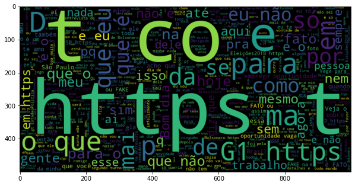

```python
plot_wordcloud(df_exp['tweet_text'])
```

- Podemos notar a alta frequência de elementos tipo "https", "t", "co", "D".

```python
df_exp['tweet_text'][df_exp['tweet_text'].apply(lambda x: 'https' in x )].shape
```

```
(36506,)
```

- Podemos notar acima que a presença de links é muito frequente, por isso o destaque de "http", "t" "co" na nuvem de palavras.

### 3.5.2 Tratamento do texto

Com base na visualização do texto, os seguintes tratamentos dos tweets são necessários:

- Exclusão de links
- Exclusão de dígitos
- Exclusão das marcações de usuários "@usuario": numerosos e pouco informativos a respeito do sentimento
- Transformação para letras minúsculas

```python
# Criação da função para processar tweets
def processa_tweets(df):

    # Coluna para os textos tratados
    df[['tweets']] = df[['tweet_text']]

    # Exclusão dos links
    df[['tweets']] = df[['tweets']].apply(lambda x: x.str.replace(r'((www\.[^\s]+)|(https?://[^\s]+))','',regex=True))

    # Exclusão dos dígitos
    df[['tweets']] = df[['tweets']].apply(lambda x: x.str.replace(r'[0-9]','',regex=True))

    # Exclusão das menções @usuario, e-mails e @ "soltas"
    df[['tweets']] = df[['tweets']].apply(lambda x: x.str.replace(r'@[^\s]+','',regex=True))
    df[['tweets']] = df[['tweets']].apply(lambda x: x.str.replace(r'[\w.+-]+@[\w-]+\.[\w.-]+','',regex=True))
    df[['tweets']] = df[['tweets']].apply(lambda x: x.str.replace('@',''))

    # Convertendo tudo para lower case
    df[['tweets']] = df[['tweets']].apply(lambda x: x.str.lower())
```

```python
# Gerando coluna 'tweets'com texto tratado
processa_tweets(df_exp)
display(df_exp.head())
display(df_exp.tail())
```

|  | id | tweet_text | tweet_date | sentiment | query_used | Data | tweets |
| --- | --- | --- | --- | --- | --- | --- | --- |
| 80275 | 1049107508105814016 | @softkirari Mas tenho alguns desse :) https://... | 2018-10-08 01:21:36+00:00 | 1 | :) | 20181008 | mas tenho alguns desse :) |
| 64878 | 1046972849427230721 | tem snap miguelito? — não, desculpa :( https:/... | 2018-10-02 03:59:13+00:00 | 0 | :( | 20181002 | tem snap miguelito? — não, desculpa :( |
| 27184 | 1046925068385890304 | @karinalouz Que pesado :( | 2018-10-02 00:49:21+00:00 | 0 | :( | 20181002 | que pesado :( |
| 65711 | 1046771718524526593 | Rio registra aumento de 55% nos tiroteios em s... | 2018-10-01 14:40:00+00:00 | 2 | estadao | 20181001 | rio registra aumento de % nos tiroteios em set... |
| 5056 | 1047487954397143041 | As alunas de Estética e Cosmetologia do Claret... | 2018-10-03 14:06:04+00:00 | 1 | :) | 20181003 | as alunas de estética e cosmetologia do claret... |

|  | id | tweet_text | tweet_date | sentiment | query_used | Data | tweets |
| --- | --- | --- | --- | --- | --- | --- | --- |
| 25279 | 1049280332267225088 | @gabih_dias Oi! Tudo bem? Você poderia, por fa... | 2018-10-08 12:48:20+00:00 | 1 | :) | 20181008 | oi! tudo bem? você poderia, por favor, nos en... |
| 87350 | 1049209076025118720 | @zelita258 Olá :) bom dia | 2018-10-08 08:05:11+00:00 | 1 | :) | 20181008 | olá :) bom dia |
| 7302 | 1046971005414051845 | Quero meu cabelo verde d volta :( https://t.co... | 2018-10-02 03:51:54+00:00 | 0 | :( | 20181002 | quero meu cabelo verde d volta :( |
| 83202 | 1045753760545308674 | Brasil tem aumento no número de doação de órgã... | 2018-09-28 19:15:00+00:00 | 2 | g1 | 20180928 | brasil tem aumento no número de doação de órgã... |
| 9639 | 1037679309350154240 | &gt;@EstadaoEconomia Petrobrás aprova mecanism... | 2018-09-06 12:30:01+00:00 | 2 | estadao | 20180906 | &gt; petrobrás aprova mecanismo que pode mante... |

### 3.5.3 Nuvens de palavras

```
Nuvem de palavras considerando todos os tweets
```

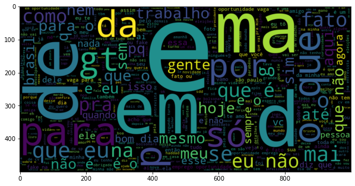

```
Nuvem de palavras considerando tweets neutros
```

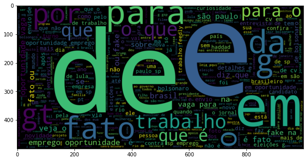

```
Nuvem de palavras considerando tweets negativos
```

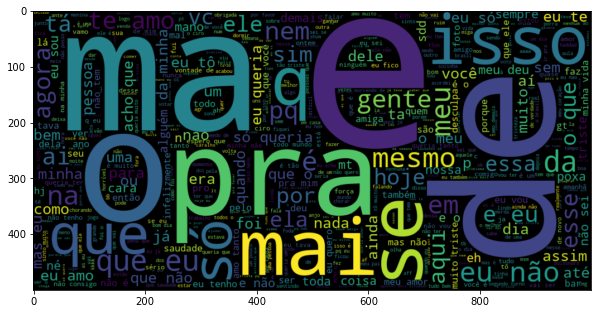

```
Nuvem de palavras considerando tweets positivos
```

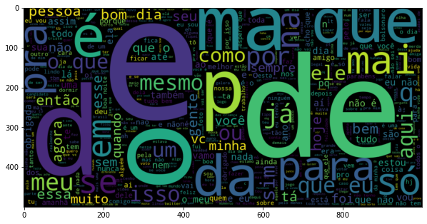

```python
print('\nNuvem de palavras considerando todos os tweets')
plot_wordcloud(df_exp['tweets'])

print('\nNuvem de palavras considerando tweets neutros')
plot_wordcloud(df_exp.loc[df_exp['sentiment'] == 2, 'tweets'])

print('\nNuvem de palavras considerando tweets negativos')
plot_wordcloud(df_exp.loc[df_exp['sentiment'] == 0, 'tweets'])

print('\nNuvem de palavras considerando tweets positivos')
plot_wordcloud(df_exp.loc[df_exp['sentiment'] == 1, 'tweets'])
```

# 4. Criando representações

## 4.1 Base de treino e de validação

- Em vista do objetivo do projeto que é desenvolver um modelo de análise de sentimento de tweets, e considerando as particularidades temporais da distribuição dos sentimementos, o processo de amostragem de uma base de treino e validação mais adequado é o "out-of-sample".

```python
from sklearn.model_selection import train_test_split
```

```python
# Separando X (coluna de textos) e y (coluna dos sentimentos)
X = df_exp['tweets']
y = df_exp['sentiment']

# Separando um conjunto de treinamento e outro de validação - 80% e 20%
X_train, X_valid, y_train, y_valid = train_test_split(X, y, test_size=.20)

print(X_train.shape, y_train.shape)
print(X_valid.shape, y_valid.shape)
```

```
(67989,) (67989,)
(16998,) (16998,)
```

## 4.2 Representação Bag of Words

#### As queries são usadas como stopwords - são excluídas dos textos

```python
# lista das queries como "stopwords"
stopwords = list(df_exp['query_used'].unique())
```

```python
from sklearn.feature_extraction.text import CountVectorizer

# Realizei alguns testes de 5000 a 15000: 10000 apresentou bons resultados
# Pré processamento do texto retirando acentuação e considerando quaisquer
# Sequências de caracteres (como os emoticons) para tokenização
# As queries são retiradas da tokenização para evitar um "efeito de rotulagem"
vectorizer_bow = CountVectorizer(max_features=10000,
                                 strip_accents='unicode',
                                 token_pattern= r'[^\s]+',
                                 stop_words=stopwords)


vectorizer_bow.fit(X_train)
```

```
CountVectorizer(max_features=10000,
                stop_words=[':)', ':(', 'estadao', 'g1', '#noticia', 'folha',
                            'veja', 'jornaloglobo', '#fato', 'exame',
                            '#oportunidade', '#trabalho', '#curiosidade',
                            '#novidade'],
                strip_accents='unicode', token_pattern='[^\\s]+')
```

```python
# Visualizando o código de algumas palavras:
vectorizer_bow.vocabulary_['casa']
```

```
2468
```

```python
# Visualizando o código de algumas palavras:
vectorizer_bow.vocabulary_[':(((']
```

```
887
```

```python
# Visualizando o código de algumas palavras:
vectorizer_bow.vocabulary_['fato']
```

```
4504
```

```python
# Codificando conjunto de treino e validação segundo BoW
X_train_bow = vectorizer_bow.transform(X_train).toarray()

print(X_train_bow.shape)

X_valid_bow = vectorizer_bow.transform(X_valid).toarray()

print(X_valid_bow.shape)
```

```
(67989, 10000)
(16998, 10000)
```

```python
from sklearn.feature_extraction.text import TfidfVectorizer

vectorizer_tfidf = CountVectorizer(max_features=10000,
                                  strip_accents='unicode',
                                  token_pattern= r'[^\s]+',
                                  stop_words=stopwords)

vectorizer_tfidf.fit(X_train)
```

```
CountVectorizer(max_features=10000,
                stop_words=[':)', ':(', 'estadao', 'g1', '#noticia', 'folha',
                            'veja', 'jornaloglobo', '#fato', 'exame',
                            '#oportunidade', '#trabalho', '#curiosidade',
                            '#novidade'],
                strip_accents='unicode', token_pattern='[^\\s]+')
```

```python
# Codificando conjunto de treino e validação segundo TF-IDF
X_train_tfidf = vectorizer_tfidf.transform(X_train).toarray()

print(X_train_tfidf.shape)

X_valid_tfidf = vectorizer_tfidf.transform(X_valid).toarray()

print(X_valid_tfidf.shape)
```

```
(67989, 10000)
(16998, 10000)
```

## 4.4 Representação Word2Vec

### 4.4.1 Funções úteis

```python
# Importação de biblioteca
from gensim.utils import simple_preprocess

# Vamos chamar essa função sempre que quisermos quebrar um texto em palavras
def tokenize(text):
    return simple_preprocess(text, min_len=1)

from tqdm import tqdm
import numpy as np

def to_word_vector(words, w2v):

    vectors = []

    for word in words:
        vectors.append(w2v.wv[word] if word in w2v.wv.key_to_index else np.zeros(w2v.vector_size))

    if not vectors:
        vectors.append(np.zeros(w2v.vector_size))

    return np.mean(vectors, axis=0)

def embeddings(x, w2v):
    x = x.copy()

    x = x.apply(tokenize)

    x = np.vstack([[to_word_vector(sentences, w2v)] for sentences in tqdm(x)])

    return x
```

### 4.4.2 Treinando o word2vec com base no dataset

```python
from gensim.models import Word2Vec

# Versão mais recente do gensim: parâmetro size virou vector_size
model_w2v = Word2Vec(
        sentences=X_train.apply(
            lambda t: tokenize(t)
        ),
         vector_size=500,
         window=5,
         min_count=1,
         workers=4
    )
```

```python
# Verificando o tamanho
len(model_w2v.wv)
```

```
51156
```

```python
# Verificando algumas palavras por semelhança
model_w2v.wv.most_similar('bolsonaro', topn=5)
```

```
[('haddad', 0.9574693441390991),
 ('lula', 0.9373349547386169),
 ('alckmin', 0.9066826701164246),
 ('marina', 0.8998019099235535),
 ('pt', 0.8977024555206299)]
```

```python
# Verificando algumas palavras por semelhança
model_w2v.wv.most_similar('bozo', topn=5)
```

```
[('coiso', 0.9793148636817932),
 ('amoedo', 0.9559447169303894),
 ('pt', 0.9480404257774353),
 ('votarem', 0.9298316240310669),
 ('ciro', 0.928669810295105)]
```

```python
# Verificando algumas palavras por semelhança
model_w2v.wv.most_similar('lula', topn=5)
```

```
[('alckmin', 0.9601977467536926),
 ('marina', 0.955176830291748),
 ('vice', 0.9456664323806763),
 ('campanha', 0.9403114914894104),
 ('temer', 0.9397255778312683)]
```

```python
# Codificando conjunto de treino e validação segundo word2vec
X_train_transformed_w2v = embeddings(X_train, model_w2v)

X_valid_transformed_w2v = embeddings(X_valid, model_w2v)
```

```python
# Visualizando as primeiras linhas do conjunto de treinamento
pd.DataFrame(X_train_transformed_w2v[:4])
```

|  | 0 | 1 | 2 | 3 | 4 | 5 | 6 | 7 | 8 | 9 | ... | 490 | 491 | 492 | 493 | 494 | 495 | 496 | 497 | 498 | 499 |
| --- | --- | --- | --- | --- | --- | --- | --- | --- | --- | --- | --- | --- | --- | --- | --- | --- | --- | --- | --- | --- | --- |
| 0 | 0.008121 | 0.187360 | 0.068770 | 0.205123 | -0.169263 | -0.108596 | -0.008952 | 0.355741 | -0.104830 | 0.042855 | ... | 0.181726 | 0.033400 | 0.115512 | 0.009726 | 0.056315 | -0.058336 | -0.108359 | 0.010794 | -0.157532 | -0.045518 |
| 1 | 0.093206 | 0.096622 | 0.293265 | 0.063198 | 0.038331 | -0.468145 | 0.087007 | 0.187228 | -0.161253 | -0.180286 | ... | -0.122817 | -0.076644 | 0.308439 | 0.077814 | 0.005373 | -0.209546 | 0.010831 | -0.143214 | 0.003253 | -0.006297 |
| 2 | 0.244364 | 0.181491 | 0.185050 | 0.164820 | -0.143745 | 0.049756 | 0.068448 | 0.388422 | -0.225955 | 0.037938 | ... | 0.209273 | 0.067687 | 0.215571 | -0.121597 | -0.023408 | -0.036059 | -0.118105 | 0.000646 | -0.152647 | -0.011562 |
| 3 | -0.078768 | 0.197805 | 0.125390 | 0.202965 | -0.164384 | -0.162961 | 0.020954 | 0.381207 | -0.216161 | -0.092333 | ... | 0.168116 | 0.089472 | 0.153709 | -0.014571 | 0.052151 | -0.188935 | -0.039518 | 0.008730 | -0.119709 | -0.066760 |

4 rows × 500 columns

# 5. Modelos

## 5.1 Funções úteis

```python
# Importação de métricas
from sklearn.metrics import accuracy_score, precision_score, recall_score, f1_score

from mlxtend.plotting import plot_confusion_matrix
from sklearn.metrics import confusion_matrix
from matplotlib import pyplot as plt

# Função para calcular e plotar as métricas do modelo
def score_modelo(y_train, y_train_pred, y_valid, y_valid_pred):

    acc_train = accuracy_score(y_train, y_train_pred)
    f1_train = f1_score(y_train, y_train_pred, average='macro')

    acc_valid = accuracy_score(y_valid, y_valid_pred)
    f1_valid = f1_score(y_valid, y_valid_pred, average='macro')

    print(f'Treino:\nAcc: {acc_train:.2f}, F1: {f1_train:.2f}')
    print(f'Validação:\nAcc: {acc_valid:.2f}, F1: {f1_valid:.2f}')


# Função para plotar a matriz de confusão do modelo
def plot_cm(y, y_pred, names):

    cm = confusion_matrix(y, y_pred)

    fig, ax = plot_confusion_matrix(conf_mat=cm, class_names=names)

    fig.set_size_inches(4, 4)

    plt.show()
```

## 5.2 Modelo aleatório

- Partimos de um modelo baseline aleatório a partir do qual iremos comparar os diversos modelos de machine learning, tais como: random forest, lightgbm, NB

```python
# Criando coluna com predições aleatórias
df_exp['y_pred_rand'] = np.random.randint(0, 3, df_exp.shape[0])
```

```python
# Coluna 'sentiment' é igual à coluna 'y_pred_rand' na proporção esperada: 1/3
print('Proporção de predições aleatórias corretas: ', end='')
print(df_exp[df_exp['sentiment']==df_exp['y_pred_rand']].shape[0]/df_exp.shape[0])
```

```
Proporção de predições aleatórias corretas: 0.3376516408391872
```

```python
# Avaliação do modelo aleatório

acc_train = accuracy_score(df_exp['sentiment'], df_exp['y_pred_rand'])
f1_train = f1_score(df_exp['sentiment'], df_exp['y_pred_rand'], average='macro')
print('\033[1m'+'\nDesempenho do modelo aleatório:'+'\033[0m')
print(f'Acc: {acc_train:.2f}, F1: {f1_train:.2f}')
```

```
Desempenho do modelo aleatório:
Acc: 0.34, F1: 0.34
```

```
Matriz de confusão do modelo aleatório:
```

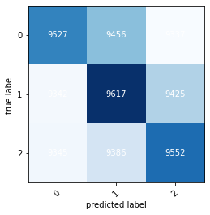

```python
print('\033[1m'+'\nMatriz de confusão do modelo aleatório:'+'\033[0m')
plot_cm(df_exp['sentiment'], df_exp['y_pred_rand'],names=['0','1','2'])
```

## 5.3 Modelo Random Forest

- Agora realizamos alguns treinamentos utilizando Random Forest para cada tipo de representação.

### 5.3.1 Random forest usando representação bag of words

```python
from sklearn.ensemble import RandomForestClassifier
```

```python
# Criação do modelo
modelo_randomForest_bow = RandomForestClassifier(n_estimators=250, max_depth=5, random_state=27)
```

```python
# Treinamento do modelo
modelo_randomForest_bow.fit(X_train_bow,y_train)
```

```
RandomForestClassifier(max_depth=5, n_estimators=250, random_state=27)
```

```python
# Predições do modelo
y_train_pred_rf_bow = modelo_randomForest_bow.predict(X_train_bow)

y_valid_pred_rf_bow = modelo_randomForest_bow.predict(X_valid_bow)

print(y_train_pred_rf_bow.shape, y_valid_pred_rf_bow.shape)
```

```
(67989,) (16998,)
```

```
Treino:
Acc: 0.75, F1: 0.75
Validação:
Acc: 0.75, F1: 0.74
```

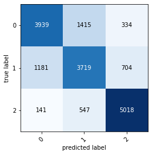

```python
# Avaliação do modelo
score_modelo(y_train, y_train_pred_rf_bow, y_valid, y_valid_pred_rf_bow)
plot_cm(y_valid, y_valid_pred_rf_bow, modelo_randomForest_bow.classes_)
```

```python
# Criação do modelo
modelo_randomForest_tfidf = RandomForestClassifier(n_estimators=250, max_depth=5, random_state=12)
# Treinamento do modelo
modelo_randomForest_tfidf.fit(X_train_tfidf, y_train)
```

```
RandomForestClassifier(max_depth=5, n_estimators=250, random_state=12)
```

```python
# Predições do modelo
y_train_pred_rf_tfidf = modelo_randomForest_tfidf.predict(X_train_tfidf)

y_valid_pred_rf_tfidf = modelo_randomForest_tfidf.predict(X_valid_tfidf)

print(y_train_pred_rf_tfidf.shape, y_valid_pred_rf_tfidf.shape)
```

```
(67989,) (16998,)
```

```
Treino:
Acc: 0.76, F1: 0.76
Validação:
Acc: 0.74, F1: 0.74
```

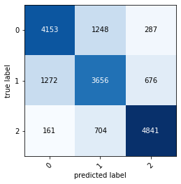

```python
# Avaliação do modelo
score_modelo(y_train, y_train_pred_rf_tfidf, y_valid, y_valid_pred_rf_tfidf)
plot_cm(y_valid, y_valid_pred_rf_tfidf, modelo_randomForest_tfidf.classes_)
```

### 5.3.3 Random forest usando representação word2vec

```python
# Criação do modelo
modelo_randomForest_w2v = RandomForestClassifier(n_estimators=250, max_depth=5, random_state=78)
# Treinamento do modelo
modelo_randomForest_w2v.fit(X_train_transformed_w2v, y_train)
```

```
RandomForestClassifier(max_depth=5, n_estimators=250, random_state=78)
```

```python
# Predições do modelo
y_train_pred_rf_w2v = modelo_randomForest_w2v.predict(X_train_transformed_w2v)

y_valid_pred_rf_w2v = modelo_randomForest_w2v.predict(X_valid_transformed_w2v)

print(y_train_pred_rf_w2v.shape, y_valid_pred_rf_w2v.shape)
```

```
(67989,) (16998,)
```

```
Treino:
Acc: 0.73, F1: 0.73
Validação:
Acc: 0.72, F1: 0.72
```

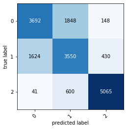

```python
# Avaliação do modelo
score_modelo(y_train, y_train_pred_rf_w2v, y_valid, y_valid_pred_rf_w2v)
plot_cm(y_valid, y_valid_pred_rf_w2v, modelo_randomForest_w2v.classes_)
```

**Considerações:**

- Segundo estes testes iniciais com modelo Random Forest e diferentes tipos de representação, o funcionamento mais promissor parecem ser com representações do tipo Bag of Words ou TF-IDF

## 5.4 Modelo lightgbm

```python
from lightgbm import LGBMClassifier
```

### 5.4.1 Modelo lightgbm com bag of words

```python
# Criação e treinamento do modelo
modelo_lgbm_bow = LGBMClassifier(n_estimators=350, max_depth=6, num_leaves=20, random_state=45)
modelo_lgbm_bow.fit(X_train_bow, y_train)
```

```
LGBMClassifier(max_depth=6, n_estimators=350, num_leaves=20, random_state=45)
```

```python
# Predições do modelo
y_train_pred_lgbm_bow = modelo_lgbm_bow.predict(X_train_bow)

y_valid_pred_lgbm_bow = modelo_lgbm_bow.predict(X_valid_bow)

print(y_train_pred_lgbm_bow.shape, y_valid_pred_lgbm_bow.shape)
```

```
(67989,) (16998,)
```

```
Treino:
Acc: 0.82, F1: 0.82
Validação:
Acc: 0.80, F1: 0.80
```

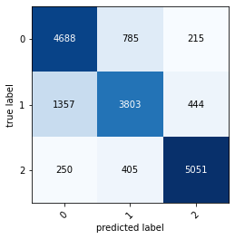

```python
# Avaliação do modelo
score_modelo(y_train, y_train_pred_lgbm_bow, y_valid, y_valid_pred_lgbm_bow)
plot_cm(y_valid, y_valid_pred_lgbm_bow, modelo_lgbm_bow.classes_)
```

```python
modelo_lgbm_tfidf = LGBMClassifier(n_estimators=350, max_depth=6, num_leaves=20, random_state=34)
modelo_lgbm_tfidf.fit(X_train_tfidf, y_train)
```

```
LGBMClassifier(max_depth=6, n_estimators=350, num_leaves=20, random_state=34)
```

```python
# Predições do modelo
y_train_pred_lgbm_tfidf = modelo_lgbm_tfidf.predict(X_train_tfidf)

y_valid_pred_lgbm_tfidf = modelo_lgbm_tfidf.predict(X_valid_tfidf)

print(y_train_pred_lgbm_tfidf.shape, y_valid_pred_lgbm_tfidf.shape)
```

```
(67989,) (16998,)
```

```
Treino:
Acc: 0.82, F1: 0.82
Validação:
Acc: 0.80, F1: 0.80
```

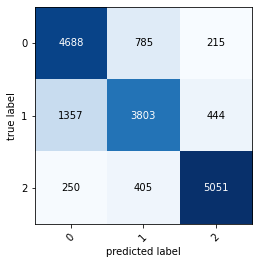

```python
# Avaliação do modelo
score_modelo(y_train, y_train_pred_lgbm_tfidf, y_valid, y_valid_pred_lgbm_tfidf)
plot_cm(y_valid, y_valid_pred_lgbm_tfidf, modelo_lgbm_tfidf.classes_)
```

### 5.4.3 Modelo lightgbm com word2vec

```python
# Criação e treino do modelo
modelo_lgbm_w2v = LGBMClassifier(n_estimators=250, max_depth=3, num_leaves=20, random_state=89)
modelo_lgbm_w2v.fit(X_train_transformed_w2v,y_train)
```

```
LGBMClassifier(max_depth=3, n_estimators=250, num_leaves=20, random_state=89)
```

```python
# Predições do modelo
y_train_pred_lgbm_w2v = modelo_lgbm_w2v.predict(X_train_transformed_w2v)

y_valid_pred_lgbm_w2v = modelo_lgbm_w2v.predict(X_valid_transformed_w2v)

print(y_train_pred_lgbm_w2v.shape, y_valid_pred_lgbm_w2v.shape)
```

```
(67989,) (16998,)
```

```
Treino:
Acc: 0.80, F1: 0.80
Validação:
Acc: 0.77, F1: 0.76
```

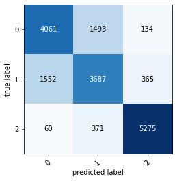

```python
# Avaliação do modelo
score_modelo(y_train, y_train_pred_lgbm_w2v, y_valid, y_valid_pred_lgbm_w2v)
plot_cm(y_valid, y_valid_pred_lgbm_w2v, modelo_lgbm_w2v.classes_)
```

**Considerações:**

- O modelo com representações w2v foi mais difícil para reduzir overfitting e aumentar a generalização.
- Os modelos como representações BoW e TF-IDF apresentaram melhor generalização na validação,

## 5.5 Modelo Naïve Bayes

- Este tipo de modelo é mais adequado para ser utilizado com representações do tipo BoW e TF-IDF.

```python
from sklearn.naive_bayes import MultinomialNB
```

### 5.5.1 Modelo Naïve Bayers com representação BoW

```python
# Criação do modelo
modelo_nb_bow = MultinomialNB()
```

```python
# Treino do modelo
modelo_nb_bow.fit(X_train_bow, y_train)
```

```
MultinomialNB()
```

```python
# Predições do modelo
y_train_pred_nb_bow = modelo_nb_bow.predict(X_train_bow)

y_valid_pred_nb_bow = modelo_nb_bow.predict(X_valid_bow)

print(y_train_pred_nb_bow.shape, y_valid_pred_nb_bow.shape)
```

```
(67989,) (16998,)
```

```python
# Avaliação do modelo
score_modelo(y_train, y_train_pred_nb_bow, y_valid, y_valid_pred_nb_bow)
plot_cm(y_valid, y_valid_pred_nb_bow, modelo_nb_bow.classes_)
```

[output not shown]

```
Treino:
Acc: 0.85, F1: 0.85
Validação:
Acc: 0.83, F1: 0.83
```

```python
# Criação do modelo
modelo_nb_tfidf = MultinomialNB()
# Treino do modelo
modelo_nb_tfidf.fit(X_train_tfidf, y_train)
```

```
MultinomialNB()
```

```python
# Predições do modelo
y_train_pred_nb_tfidf = modelo_nb_tfidf.predict(X_train_tfidf)

y_valid_pred_nb_tfidf = modelo_nb_tfidf.predict(X_valid_tfidf)

print(y_train_pred_nb_tfidf.shape, y_valid_pred_nb_tfidf.shape)
```

```
(67989,) (16998,)
```

```python
# Avaliação do modelo
score_modelo(y_train, y_train_pred_nb_tfidf, y_valid, y_valid_pred_nb_tfidf)
plot_cm(y_valid, y_valid_pred_nb_tfidf, modelo_nb_tfidf.classes_)
```

[output not shown]

```
Treino:
Acc: 0.85, F1: 0.85
Validação:
Acc: 0.83, F1: 0.83
```

# 6. Otimização de um modelo

Modelo LGBM com BoW (acc ==0.80)

```python
# Criação e treinamento do modelo
modelo_lgbm_bow = LGBMClassifier(n_estimators=350, max_depth=6, num_leaves=20, random_state=45)
modelo_lgbm_bow.fit(X_train_bow, y_train)
```

```
LGBMClassifier(max_depth=6, n_estimators=350, num_leaves=20, random_state=45)
```

```python
from sklearn.model_selection import GridSearchCV
```

```python
modelo_gs = LGBMClassifier()

parameters = {
    'max_depth': [5, 6, 7, 8],
    'n_estimators': [350, 400],
    'num_leaves': [20]

}

clf = GridSearchCV(modelo_gs, parameters, verbose=3, scoring='accuracy', cv=3)

clf.fit(X_train_bow, y_train)
```

```
Fitting 3 folds for each of 8 candidates, totalling 24 fits
[CV 1/3] END max_depth=5, n_estimators=350, num_leaves=20;, score=0.792 total time=  26.1s
[CV 2/3] END max_depth=5, n_estimators=350, num_leaves=20;, score=0.794 total time=  24.6s
[CV 3/3] END max_depth=5, n_estimators=350, num_leaves=20;, score=0.796 total time=  24.3s
[CV 1/3] END max_depth=5, n_estimators=400, num_leaves=20;, score=0.796 total time=  25.6s
[CV 2/3] END max_depth=5, n_estimators=400, num_leaves=20;, score=0.797 total time=  27.3s
[CV 3/3] END max_depth=5, n_estimators=400, num_leaves=20;, score=0.800 total time=  25.6s
[CV 1/3] END max_depth=6, n_estimators=350, num_leaves=20;, score=0.797 total time=  24.5s
[CV 2/3] END max_depth=6, n_estimators=350, num_leaves=20;, score=0.796 total time=  24.9s
[CV 3/3] END max_depth=6, n_estimators=350, num_leaves=20;, score=0.801 total time=  26.0s
[CV 1/3] END max_depth=6, n_estimators=400, num_leaves=20;, score=0.801 total time=  25.6s
[CV 2/3] END max_depth=6, n_estimators=400, num_leaves=20;, score=0.799 total time=  26.8s
[CV 3/3] END max_depth=6, n_estimators=400, num_leaves=20;, score=0.802 total time=  26.6s
[CV 1/3] END max_depth=7, n_estimators=350, num_leaves=20;, score=0.799 total time=  25.6s
[CV 2/3] END max_depth=7, n_estimators=350, num_leaves=20;, score=0.798 total time=  27.0s
[CV 3/3] END max_depth=7, n_estimators=350, num_leaves=20;, score=0.802 total time=  25.6s
[CV 1/3] END max_depth=7, n_estimators=400, num_leaves=20;, score=0.802 total time=  32.9s
[CV 2/3] END max_depth=7, n_estimators=400, num_leaves=20;, score=0.800 total time=  30.3s
[CV 3/3] END max_depth=7, n_estimators=400, num_leaves=20;, score=0.805 total time=  31.3s
[CV 1/3] END max_depth=8, n_estimators=350, num_leaves=20;, score=0.802 total time=  27.6s
[CV 2/3] END max_depth=8, n_estimators=350, num_leaves=20;, score=0.801 total time=  31.2s
[CV 3/3] END max_depth=8, n_estimators=350, num_leaves=20;, score=0.805 total time=  29.5s
[CV 1/3] END max_depth=8, n_estimators=400, num_leaves=20;, score=0.805 total time=  31.6s
[CV 2/3] END max_depth=8, n_estimators=400, num_leaves=20;, score=0.803 total time=  30.2s
[CV 3/3] END max_depth=8, n_estimators=400, num_leaves=20;, score=0.806 total time=  55.2s
```

```
GridSearchCV(cv=3, estimator=LGBMClassifier(),
             param_grid={'max_depth': [5, 6, 7, 8], 'n_estimators': [350, 400],
                         'num_leaves': [20]},
             scoring='accuracy', verbose=3)
```

```python
clf.best_params_
```

```
{'max_depth': 8, 'n_estimators': 400, 'num_leaves': 20}
```

```python
# Criação e treinamento do modelo
modelo_lgbm_bow = LGBMClassifier(n_estimators=400, max_depth=8, num_leaves=20, random_state=45)
modelo_lgbm_bow.fit(X_train_bow, y_train)
```

```
LGBMClassifier(max_depth=8, n_estimators=400, num_leaves=20, random_state=45)
```

```python
# Predições do modelo
y_train_pred_lgbm_bow = modelo_lgbm_bow.predict(X_train_bow)

y_valid_pred_lgbm_bow = modelo_lgbm_bow.predict(X_valid_bow)

print(y_train_pred_lgbm_bow.shape, y_valid_pred_lgbm_bow.shape)
```

```
(67989,) (16998,)
```

```
Treino:
Acc: 0.84, F1: 0.84
Validação:
Acc: 0.81, F1: 0.80
```

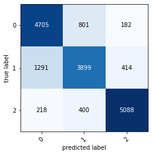

```python
# Avaliação do modelo
score_modelo(y_train, y_train_pred_lgbm_bow, y_valid, y_valid_pred_lgbm_bow)
plot_cm(y_valid, y_valid_pred_lgbm_bow, modelo_lgbm_bow.classes_)
```

**Observação:** Após o gridsearch, o desempenho em teste foi de .80 para .81, ficando abaixo do desempenho do modelo NB com representações BoW (.83)

# 7. Modelo definitivo

### Naïve Bayes e BoW

O modelo selecionado é o Naïve Bayes com representação Bag of Words. Mostramos ele abaixo: seu desempenho em treino e validação. Em seguida, rodamos o modelo com o conjunto de teste (df_test). Posteriormente, rodamos o conjunto de submissão.

```python
# Modelo escolhido: modelo_nb_bow.predict(X_train_bow)
```

```python
# Avaliação do modelo
print('\nDesempenho do modelo em treino e validação:')
score_modelo(y_train, y_train_pred_nb_bow, y_valid, y_valid_pred_nb_bow)
print('\nMatriz de confusão da validação:')
plot_cm(y_valid, y_valid_pred_nb_bow, modelo_nb_bow.classes_)
```

[output not shown]

```
Desempenho do modelo em treino e validação:
Treino:
Acc: 0.85, F1: 0.85
Validação:
Acc: 0.83, F1: 0.83

Matriz de confusão da validação:
```

### Teste do modelo

```python
df_test.head(3)
```

|  | id | tweet_text | tweet_date | sentiment | query_used |
| --- | --- | --- | --- | --- | --- |
| 10 | 1046931349075058688 | @uttsrenjun ai n da eu to mto apaixonada no re... | Tue Oct 02 01:14:19 +0000 2018 | 0 | :( |
| 18 | 1046937038564548608 | @kdkelv pena que não surge efeito :( | Tue Oct 02 01:36:55 +0000 2018 | 0 | :( |
| 20 | 1045462190814310401 | @DiorFgomes @Teledramaturgia Exato! Minha perg... | Thu Sep 27 23:56:24 +0000 2018 | 1 | :) |

```python
# Gerando coluna 'tweets'com texto tratado
processa_tweets(df_test)
display(df_test.head())
display(df_test.tail())
```

|  | id | tweet_text | tweet_date | sentiment | query_used | tweets |
| --- | --- | --- | --- | --- | --- | --- |
| 10 | 1046931349075058688 | @uttsrenjun ai n da eu to mto apaixonada no re... | Tue Oct 02 01:14:19 +0000 2018 | 0 | :( | ai n da eu to mto apaixonada no renjun :((( |
| 18 | 1046937038564548608 | @kdkelv pena que não surge efeito :( | Tue Oct 02 01:36:55 +0000 2018 | 0 | :( | pena que não surge efeito :( |
| 20 | 1045462190814310401 | @DiorFgomes @Teledramaturgia Exato! Minha perg... | Thu Sep 27 23:56:24 +0000 2018 | 1 | :) | exato! minha pergunta era sobre pessoas norm... |
| 41 | 1049285744341213184 | @zjmarvell Já solicitei mana :) | Mon Oct 08 13:09:50 +0000 2018 | 1 | :) | já solicitei mana :) |
| 43 | 1045885883084201984 | Letícia Birkheuer antecipa pedido para 2019: '... | Sat Sep 29 04:00:00 +0000 2018 | 2 | jornaloglobo | letícia birkheuer antecipa pedido para : 'um a... |

|  | id | tweet_text | tweet_date | sentiment | query_used | tweets |
| --- | --- | --- | --- | --- | --- | --- |
| 94938 | 1049235876415492096 | @_LidiaRamos_ Não gostaria de perder esse livr... | Mon Oct 08 09:51:41 +0000 2018 | 0 | :( | não gostaria de perder esse livre árbitrio :( |
| 94949 | 1046379451368583168 | Japão: tufão Trami causa cancelamento de voos ... | Sun Sep 30 12:41:16 +0000 2018 | 2 | exame | japão: tufão trami causa cancelamento de voos ... |
| 94966 | 1049309498232512514 | @fpsknight Eu perdi mais de 30 seguidores HAHA... | Mon Oct 08 14:44:14 +0000 2018 | 0 | :( | eu perdi mais de seguidores hahahaha e não d... |
| 94990 | 1045449336182775809 | felicidade: [27/9 19:41] Mell✨: Queria uma piz... | Thu Sep 27 23:05:19 +0000 2018 | 1 | :) | felicidade: [/ :] mell✨: queria uma pizza agr ... |
| 94996 | 1032352892194369536 | #Oportunidade ➡️ Venha fazer parte da nossa eq... | Wed Aug 22 19:44:44 +0000 2018 | 2 | #oportunidade | #oportunidade ➡️ venha fazer parte da nossa eq... |

```python
# Separando os dados de teste: 'tweets' e 'sentiment'
X_test = df_test['tweets']
y_test = df_test['sentiment']
```

```python
# Codificando conjunto de teste segundo BoW
X_test_bow = vectorizer_bow.transform(X_test).toarray()

print(X_test_bow.shape)
```

```
(10000, 10000)
```

```python
y_pred_test = modelo_nb_bow.predict(X_test_bow)
```

```python
# Desempenho do modelo em teste

acc_test = accuracy_score(y_test, y_pred_test)
f1_test = f1_score(y_test, y_pred_test, average='macro')
print('\033[1m'+'\nDesempenho do modelo no teste:'+'\033[0m')
print(f'Acc: {acc_test:.2f}, F1: {f1_test:.2f}')
```

```
Desempenho do modelo no teste:
Acc: 0.83, F1: 0.83
```

Note que o desempenho do modelo em teste é similar ao desempenho em validação, indicando que o modelo foi desenvolvido adequadamente e generaliza para um conjunto de dados inéditos, não utilizados durante o desenvolvimento do modelo.

# Submissão

Aqui, temos um conjunto de submissão para simlular o uso do modelo em contexto similar ao realístico, isto é, um conjunto de dados ainda sem classificação e não utilizado durante o desenvolvimento do modelo.

```python
df_subm = pd.read_csv('Dados/subm/Subm3classes.csv')
display(df_subm.head())
```

|  | id | tweet_text | tweet_date | query_used |
| --- | --- | --- | --- | --- |
| 0 | 1046764676707753987 | Apartamento Vila Mariana Praça Monteiro dos Sa... | Mon Oct 01 14:12:01 +0000 2018 | :) |
| 1 | 1047329264943751169 | @FalleNCS @BrasilGameShow quero 1x1 de scout. ... | Wed Oct 03 03:35:29 +0000 2018 | :) |
| 2 | 1045443874947313665 | mais uma analógica no correio à minha espera :... | Thu Sep 27 22:43:37 +0000 2018 | :) |
| 3 | 1040484298711814144 | Em festa de posse como presidente do STF, Toff... | Fri Sep 14 06:16:02 +0000 2018 | folha |
| 4 | 1045411876887306240 | @thethiagor @jubsilva @GSCISA @GrupoMulheRIs A... | Thu Sep 27 20:36:28 +0000 2018 | :) |

```python
# Gerando coluna 'tweets'com texto tratado
processa_tweets(df_subm)
display(df_subm.head())
```

|  | id | tweet_text | tweet_date | query_used | tweets |
| --- | --- | --- | --- | --- | --- |
| 0 | 1046764676707753987 | Apartamento Vila Mariana Praça Monteiro dos Sa... | Mon Oct 01 14:12:01 +0000 2018 | :) | apartamento vila mariana praça monteiro dos sa... |
| 1 | 1047329264943751169 | @FalleNCS @BrasilGameShow quero 1x1 de scout. ... | Wed Oct 03 03:35:29 +0000 2018 | :) | quero x de scout. dizem que dou muita bala c... |
| 2 | 1045443874947313665 | mais uma analógica no correio à minha espera :... | Thu Sep 27 22:43:37 +0000 2018 | :) | mais uma analógica no correio à minha espera :... |
| 3 | 1040484298711814144 | Em festa de posse como presidente do STF, Toff... | Fri Sep 14 06:16:02 +0000 2018 | folha | em festa de posse como presidente do stf, toff... |
| 4 | 1045411876887306240 | @thethiagor @jubsilva @GSCISA @GrupoMulheRIs A... | Thu Sep 27 20:36:28 +0000 2018 | :) | a flávia tem tuiter também :) |

```python
# Separando os dados da submissão
X_subm = df_subm['tweets']

# Convertendo para BoW
X_subm_bow = vectorizer_bow.transform(X_subm).toarray()

print(X_subm_bow.shape)
```

```
(5000, 10000)
```

```python
y_pred_subm = modelo_nb_bow.predict(X_subm_bow)
y_pred_subm.shape
```

```
(5000,)
```

```python
submission = pd.DataFrame()
submission['id'] = df_subm['id']
submission['sentiment_predict'] = y_pred_subm
submission.head()
```

|  | id | sentiment_predict |
| --- | --- | --- |
| 0 | 1046764676707753987 | 1 |
| 1 | 1047329264943751169 | 1 |
| 2 | 1045443874947313665 | 1 |
| 3 | 1040484298711814144 | 2 |
| 4 | 1045411876887306240 | 1 |

```python
submission.to_csv('Subm3classes_classificado.csv',index=False)
```